> **Tip**: Welcome to the Investigate a Dataset project! You will find tips in quoted sections like this to help organize your approach to your investigation. Once you complete this project, remove these **Tip** sections from your report before submission. First things first, you might want to double-click this Markdown cell and change the title so that it reflects your dataset and investigation.

# Project: US Census and FBI Gun Data Analysis

- Introduction
- Data Wrangling
- Exploratory Data Analysis
- Conclusions

## Introduction

### Dataset Description

Two datasets have been selected for this analysis. The FBI's National Instant Criminal Background Check System (NCIS) data which contains the number of firearm checks by month, state, and the typecomes; and the U.S. census data which contains information about the population and demographic as of July 1, 2016 and April 1,2010. The NICS is used by to determine whether a prospective buyer is eligible to buy firearms or explosives. Gun shops call into this system to ensure that each customer does not have a criminal record or isn’t otherwise ineligible to make a purchase. Both dataset are connected by states, therefore, we can compare the changes in gun registration and population by states.

### Question(s) for Analysis

Which states have the highest and the lowest gun registrations? Which states have had the highest growth in gun registrations? What is the overall trend of gun purchases? Is the change in population correlated with the change in gun purchases?

```python
# Use this cell to set up import statements for all of the packages that you plan to use

import pandas as pd
import numpy as np
import matplotlib.pyplot as plt
% matplotlib inline

np.set_printoptions(suppress=True)


# Remember to include a 'magic word' so that your visualizations are plotted inline with the notebook. See this page for more:
# http://ipython.readthedocs.io/en/stable/interactive/magics.html
```

```python
# Upgrade pandas to use dataframe.explode() function.
!pip install --upgrade pandas==0.25.0
```

## Data Wrangling

```python
# Load your data and print out a few lines. Perform operations to inspect data types and look for instances of missing or possibly errant data.

df_gun_purchase = pd.read_excel("gun_data[1].xlsx")
df_census_data = pd.read_csv("U.S._Census_Data[1].csv")
```

```python
#check for the data structure of the df_gun_purchase

df_gun_purchase.info()
```

```
<class 'pandas.core.frame.DataFrame'>
RangeIndex: 12485 entries, 0 to 12484
Data columns (total 27 columns):
month                        12485 non-null object
state                        12485 non-null object
permit                       12461 non-null float64
permit_recheck               1100 non-null float64
handgun                      12465 non-null float64
long_gun                     12466 non-null float64
other                        5500 non-null float64
multiple                     12485 non-null int64
admin                        12462 non-null float64
prepawn_handgun              10542 non-null float64
prepawn_long_gun             10540 non-null float64
prepawn_other                5115 non-null float64
redemption_handgun           10545 non-null float64
redemption_long_gun          10544 non-null float64
redemption_other             5115 non-null float64
returned_handgun             2200 non-null float64
returned_long_gun            2145 non-null float64
returned_other               1815 non-null float64
rentals_handgun              990 non-null float64
rentals_long_gun             825 non-null float64
private_sale_handgun         2750 non-null float64
private_sale_long_gun        2750 non-null float64
private_sale_other           2750 non-null float64
return_to_seller_handgun     2475 non-null float64
return_to_seller_long_gun    2750 non-null float64
return_to_seller_other       2255 non-null float64
totals                       12485 non-null int64
dtypes: float64(23), int64(2), object(2)
memory usage: 2.6+ MB
```

```python
#check for the composition of the first five rows in the df_gun_purchase

df_gun_purchase.head()
```

|  | month | state | permit | permit_recheck | handgun | long_gun | other | multiple | admin | prepawn_handgun | ... | returned_other | rentals_handgun | rentals_long_gun | private_sale_handgun | private_sale_long_gun | private_sale_other | return_to_seller_handgun | return_to_seller_long_gun | return_to_seller_other | totals |
| --- | --- | --- | --- | --- | --- | --- | --- | --- | --- | --- | --- | --- | --- | --- | --- | --- | --- | --- | --- | --- | --- |
| 0 | 2017-09 | Alabama | 16717.0 | 0.0 | 5734.0 | 6320.0 | 221.0 | 317 | 0.0 | 15.0 | ... | 0.0 | 0.0 | 0.0 | 9.0 | 16.0 | 3.0 | 0.0 | 0.0 | 3.0 | 32019 |
| 1 | 2017-09 | Alaska | 209.0 | 2.0 | 2320.0 | 2930.0 | 219.0 | 160 | 0.0 | 5.0 | ... | 0.0 | 0.0 | 0.0 | 17.0 | 24.0 | 1.0 | 0.0 | 0.0 | 0.0 | 6303 |
| 2 | 2017-09 | Arizona | 5069.0 | 382.0 | 11063.0 | 7946.0 | 920.0 | 631 | 0.0 | 13.0 | ... | 0.0 | 0.0 | 0.0 | 38.0 | 12.0 | 2.0 | 0.0 | 0.0 | 0.0 | 28394 |
| 3 | 2017-09 | Arkansas | 2935.0 | 632.0 | 4347.0 | 6063.0 | 165.0 | 366 | 51.0 | 12.0 | ... | 0.0 | 0.0 | 0.0 | 13.0 | 23.0 | 0.0 | 0.0 | 2.0 | 1.0 | 17747 |
| 4 | 2017-09 | California | 57839.0 | 0.0 | 37165.0 | 24581.0 | 2984.0 | 0 | 0.0 | 0.0 | ... | 0.0 | 0.0 | 0.0 | 0.0 | 0.0 | 0.0 | 0.0 | 0.0 | 0.0 | 123506 |

5 rows × 27 columns

```python
#check for the composition of the last five rows in the df_gun_purchase

df_gun_purchase.tail()
```

|  | month | state | permit | permit_recheck | handgun | long_gun | other | multiple | admin | prepawn_handgun | ... | returned_other | rentals_handgun | rentals_long_gun | private_sale_handgun | private_sale_long_gun | private_sale_other | return_to_seller_handgun | return_to_seller_long_gun | return_to_seller_other | totals |
| --- | --- | --- | --- | --- | --- | --- | --- | --- | --- | --- | --- | --- | --- | --- | --- | --- | --- | --- | --- | --- | --- |
| 12480 | 1998-11 | Virginia | 0.0 | NaN | 14.0 | 2.0 | NaN | 8 | 0.0 | NaN | ... | NaN | NaN | NaN | NaN | NaN | NaN | NaN | NaN | NaN | 24 |
| 12481 | 1998-11 | Washington | 1.0 | NaN | 65.0 | 286.0 | NaN | 8 | 1.0 | NaN | ... | NaN | NaN | NaN | NaN | NaN | NaN | NaN | NaN | NaN | 361 |
| 12482 | 1998-11 | West Virginia | 3.0 | NaN | 149.0 | 251.0 | NaN | 5 | 0.0 | NaN | ... | NaN | NaN | NaN | NaN | NaN | NaN | NaN | NaN | NaN | 408 |
| 12483 | 1998-11 | Wisconsin | 0.0 | NaN | 25.0 | 214.0 | NaN | 2 | 0.0 | NaN | ... | NaN | NaN | NaN | NaN | NaN | NaN | NaN | NaN | NaN | 241 |
| 12484 | 1998-11 | Wyoming | 8.0 | NaN | 45.0 | 49.0 | NaN | 5 | 0.0 | NaN | ... | NaN | NaN | NaN | NaN | NaN | NaN | NaN | NaN | NaN | 107 |

5 rows × 27 columns

```python
#check for duplication in the df_gun_purchase dataframe

df_gun_purchase.duplicated().sum()
```

```
0
```

```python
# check sum of all null values in df_gun_purchase dataframe
df_gun_purchase.isnull().sum()
```

```
month                            0
state                            0
permit                          24
permit_recheck               11385
handgun                         20
long_gun                        19
other                         6985
multiple                         0
admin                           23
prepawn_handgun               1943
prepawn_long_gun              1945
prepawn_other                 7370
redemption_handgun            1940
redemption_long_gun           1941
redemption_other              7370
returned_handgun             10285
returned_long_gun            10340
returned_other               10670
rentals_handgun              11495
rentals_long_gun             11660
private_sale_handgun          9735
private_sale_long_gun         9735
private_sale_other            9735
return_to_seller_handgun     10010
return_to_seller_long_gun     9735
return_to_seller_other       10230
totals                           0
dtype: int64
```

```python
#check for number of rows and columns in df_gun_purchase
df_gun_purchase.shape
```

```
(12485, 27)
```

```python
# check for the datatype of each columns of the df_gun_purchase dataset
df_gun_purchase.dtypes
```

```
month                         object
state                         object
permit                       float64
permit_recheck               float64
handgun                      float64
long_gun                     float64
other                        float64
multiple                       int64
admin                        float64
prepawn_handgun              float64
prepawn_long_gun             float64
prepawn_other                float64
redemption_handgun           float64
redemption_long_gun          float64
redemption_other             float64
returned_handgun             float64
returned_long_gun            float64
returned_other               float64
rentals_handgun              float64
rentals_long_gun             float64
private_sale_handgun         float64
private_sale_long_gun        float64
private_sale_other           float64
return_to_seller_handgun     float64
return_to_seller_long_gun    float64
return_to_seller_other       float64
totals                         int64
dtype: object
```

```python
# check the number of rows and columns in the census dataframe
df_census_data.shape
```

```
(85, 52)
```

```python
# Review the first 5 rows of the dataset

df_census_data.head()
```

|  | Fact | Fact Note | Alabama | Alaska | Arizona | Arkansas | California | Colorado | Connecticut | Delaware | ... | South Dakota | Tennessee | Texas | Utah | Vermont | Virginia | Washington | West Virginia | Wisconsin | Wyoming |
| --- | --- | --- | --- | --- | --- | --- | --- | --- | --- | --- | --- | --- | --- | --- | --- | --- | --- | --- | --- | --- | --- |
| 0 | Population estimates, July 1, 2016, (V2016) | NaN | 4,863,300 | 741,894 | 6,931,071 | 2,988,248 | 39,250,017 | 5,540,545 | 3,576,452 | 952,065 | ... | 865454 | 6651194 | 27,862,596 | 3,051,217 | 624,594 | 8,411,808 | 7,288,000 | 1,831,102 | 5,778,708 | 585,501 |
| 1 | Population estimates base, April 1, 2010, (V2... | NaN | 4,780,131 | 710,249 | 6,392,301 | 2,916,025 | 37,254,522 | 5,029,324 | 3,574,114 | 897,936 | ... | 814195 | 6346298 | 25,146,100 | 2,763,888 | 625,741 | 8,001,041 | 6,724,545 | 1,853,011 | 5,687,289 | 563,767 |
| 2 | Population, percent change - April 1, 2010 (es... | NaN | 1.70% | 4.50% | 8.40% | 2.50% | 5.40% | 10.20% | 0.10% | 6.00% | ... | 0.063 | 0.048 | 10.80% | 10.40% | -0.20% | 5.10% | 8.40% | -1.20% | 1.60% | 3.90% |
| 3 | Population, Census, April 1, 2010 | NaN | 4,779,736 | 710,231 | 6,392,017 | 2,915,918 | 37,253,956 | 5,029,196 | 3,574,097 | 897,934 | ... | 814180 | 6346105 | 25,145,561 | 2,763,885 | 625,741 | 8,001,024 | 6,724,540 | 1,852,994 | 5,686,986 | 563,626 |
| 4 | Persons under 5 years, percent, July 1, 2016, ... | NaN | 6.00% | 7.30% | 6.30% | 6.40% | 6.30% | 6.10% | 5.20% | 5.80% | ... | 0.071 | 0.061 | 7.20% | 8.30% | 4.90% | 6.10% | 6.20% | 5.50% | 5.80% | 6.50% |

5 rows × 52 columns

```python
# Review the last 25 rows of the dataset

df_census_data.tail(25)
```

|  | Fact | Fact Note | Alabama | Alaska | Arizona | Arkansas | California | Colorado | Connecticut | Delaware | ... | South Dakota | Tennessee | Texas | Utah | Vermont | Virginia | Washington | West Virginia | Wisconsin | Wyoming |
| --- | --- | --- | --- | --- | --- | --- | --- | --- | --- | --- | --- | --- | --- | --- | --- | --- | --- | --- | --- | --- | --- |
| 60 | Veteran-owned firms, 2012 | NaN | 41,943 | 7,953 | 46,780 | 25,915 | 252,377 | 51,722 | 31,056 | 7,206 | ... | 8604 | 59379 | 213,590 | 18,754 | 8,237 | 76,434 | 49,331 | 12,912 | 39,830 | 6,470 |
| 61 | Nonveteran-owned firms, 2012 | NaN | 316,984 | 56,091 | 427,582 | 192,988 | 3,176,341 | 469,524 | 281,182 | 60,318 | ... | 66219 | 469392 | 2,057,218 | 219,807 | 63,317 | 548,439 | 461,401 | 94,960 | 370,755 | 51,353 |
| 62 | Population per square mile, 2010 | NaN | 94.4 | 1.2 | 56.3 | 56 | 239.1 | 48.5 | 738.1 | 460.8 | ... | 10.7 | 153.9 | 96.3 | 33.6 | 67.9 | 202.6 | 101.2 | 77.1 | 105 | 5.8 |
| 63 | Land area in square miles, 2010 | NaN | 50,645.33 | 570,640.95 | 113,594.08 | 52,035.48 | 155,779.22 | 103,641.89 | 4,842.36 | 1,948.54 | ... | 75811 | 41234.9 | 261,231.71 | 82,169.62 | 9,216.66 | 39,490.09 | 66,455.52 | 24,038.21 | 54,157.80 | 97,093.14 |
| 64 | FIPS Code | NaN | "01" | "02" | "04" | "05" | "06" | "08" | "09" | "10" | ... | "46" | "47" | "48" | "49" | "50" | "51" | "53" | "54" | "55" | "56" |
| 65 | NaN | NaN | NaN | NaN | NaN | NaN | NaN | NaN | NaN | NaN | ... | NaN | NaN | NaN | NaN | NaN | NaN | NaN | NaN | NaN | NaN |
| 66 | NOTE: FIPS Code values are enclosed in quotes ... | NaN | NaN | NaN | NaN | NaN | NaN | NaN | NaN | NaN | ... | NaN | NaN | NaN | NaN | NaN | NaN | NaN | NaN | NaN | NaN |
| 67 | NaN | NaN | NaN | NaN | NaN | NaN | NaN | NaN | NaN | NaN | ... | NaN | NaN | NaN | NaN | NaN | NaN | NaN | NaN | NaN | NaN |
| 68 | Value Notes | NaN | NaN | NaN | NaN | NaN | NaN | NaN | NaN | NaN | ... | NaN | NaN | NaN | NaN | NaN | NaN | NaN | NaN | NaN | NaN |
| 69 | 1 | Includes data not distributed by county. | NaN | NaN | NaN | NaN | NaN | NaN | NaN | NaN | ... | NaN | NaN | NaN | NaN | NaN | NaN | NaN | NaN | NaN | NaN |
| 70 | NaN | NaN | NaN | NaN | NaN | NaN | NaN | NaN | NaN | NaN | ... | NaN | NaN | NaN | NaN | NaN | NaN | NaN | NaN | NaN | NaN |
| 71 | Fact Notes | NaN | NaN | NaN | NaN | NaN | NaN | NaN | NaN | NaN | ... | NaN | NaN | NaN | NaN | NaN | NaN | NaN | NaN | NaN | NaN |
| 72 | (a) | Includes persons reporting only one race | NaN | NaN | NaN | NaN | NaN | NaN | NaN | NaN | ... | NaN | NaN | NaN | NaN | NaN | NaN | NaN | NaN | NaN | NaN |
| 73 | (b) | Hispanics may be of any race, so also are incl... | NaN | NaN | NaN | NaN | NaN | NaN | NaN | NaN | ... | NaN | NaN | NaN | NaN | NaN | NaN | NaN | NaN | NaN | NaN |
| 74 | (c) | Economic Census - Puerto Rico data are not com... | NaN | NaN | NaN | NaN | NaN | NaN | NaN | NaN | ... | NaN | NaN | NaN | NaN | NaN | NaN | NaN | NaN | NaN | NaN |
| 75 | NaN | NaN | NaN | NaN | NaN | NaN | NaN | NaN | NaN | NaN | ... | NaN | NaN | NaN | NaN | NaN | NaN | NaN | NaN | NaN | NaN |
| 76 | Value Flags | NaN | NaN | NaN | NaN | NaN | NaN | NaN | NaN | NaN | ... | NaN | NaN | NaN | NaN | NaN | NaN | NaN | NaN | NaN | NaN |
| 77 | - | Either no or too few sample observations were ... | NaN | NaN | NaN | NaN | NaN | NaN | NaN | NaN | ... | NaN | NaN | NaN | NaN | NaN | NaN | NaN | NaN | NaN | NaN |
| 78 | D | Suppressed to avoid disclosure of confidential... | NaN | NaN | NaN | NaN | NaN | NaN | NaN | NaN | ... | NaN | NaN | NaN | NaN | NaN | NaN | NaN | NaN | NaN | NaN |
| 79 | F | Fewer than 25 firms | NaN | NaN | NaN | NaN | NaN | NaN | NaN | NaN | ... | NaN | NaN | NaN | NaN | NaN | NaN | NaN | NaN | NaN | NaN |
| 80 | FN | Footnote on this item in place of data | NaN | NaN | NaN | NaN | NaN | NaN | NaN | NaN | ... | NaN | NaN | NaN | NaN | NaN | NaN | NaN | NaN | NaN | NaN |
| 81 | NaN | Not available | NaN | NaN | NaN | NaN | NaN | NaN | NaN | NaN | ... | NaN | NaN | NaN | NaN | NaN | NaN | NaN | NaN | NaN | NaN |
| 82 | S | Suppressed; does not meet publication standards | NaN | NaN | NaN | NaN | NaN | NaN | NaN | NaN | ... | NaN | NaN | NaN | NaN | NaN | NaN | NaN | NaN | NaN | NaN |
| 83 | X | Not applicable | NaN | NaN | NaN | NaN | NaN | NaN | NaN | NaN | ... | NaN | NaN | NaN | NaN | NaN | NaN | NaN | NaN | NaN | NaN |
| 84 | Z | Value greater than zero but less than half uni... | NaN | NaN | NaN | NaN | NaN | NaN | NaN | NaN | ... | NaN | NaN | NaN | NaN | NaN | NaN | NaN | NaN | NaN | NaN |

25 rows × 52 columns

```python
# check the data structure of the census data
df_census_data.info()
```

```
<class 'pandas.core.frame.DataFrame'>
RangeIndex: 85 entries, 0 to 84
Data columns (total 52 columns):
Fact              80 non-null object
Fact Note         28 non-null object
Alabama           65 non-null object
Alaska            65 non-null object
Arizona           65 non-null object
Arkansas          65 non-null object
California        65 non-null object
Colorado          65 non-null object
Connecticut       65 non-null object
Delaware          65 non-null object
Florida           65 non-null object
Georgia           65 non-null object
Hawaii            65 non-null object
Idaho             65 non-null object
Illinois          65 non-null object
Indiana           65 non-null object
Iowa              65 non-null object
Kansas            65 non-null object
Kentucky          65 non-null object
Louisiana         65 non-null object
Maine             65 non-null object
Maryland          65 non-null object
Massachusetts     65 non-null object
Michigan          65 non-null object
Minnesota         65 non-null object
Mississippi       65 non-null object
Missouri          65 non-null object
Montana           65 non-null object
Nebraska          65 non-null object
Nevada            65 non-null object
New Hampshire     65 non-null object
New Jersey        65 non-null object
New Mexico        65 non-null object
New York          65 non-null object
North Carolina    65 non-null object
North Dakota      65 non-null object
Ohio              65 non-null object
Oklahoma          65 non-null object
Oregon            65 non-null object
Pennsylvania      65 non-null object
Rhode Island      65 non-null object
South Carolina    65 non-null object
South Dakota      65 non-null object
Tennessee         65 non-null object
Texas             65 non-null object
Utah              65 non-null object
Vermont           65 non-null object
Virginia          65 non-null object
Washington        65 non-null object
West Virginia     65 non-null object
Wisconsin         65 non-null object
Wyoming           65 non-null object
dtypes: object(52)
memory usage: 34.7+ KB
```

```python
#check for duplication in the census dataset
print(df_census_data.duplicated().sum())
df_census_data[df_census_data.duplicated()]
```

```
3
```

|  | Fact | Fact Note | Alabama | Alaska | Arizona | Arkansas | California | Colorado | Connecticut | Delaware | ... | South Dakota | Tennessee | Texas | Utah | Vermont | Virginia | Washington | West Virginia | Wisconsin | Wyoming |
| --- | --- | --- | --- | --- | --- | --- | --- | --- | --- | --- | --- | --- | --- | --- | --- | --- | --- | --- | --- | --- | --- |
| 67 | NaN | NaN | NaN | NaN | NaN | NaN | NaN | NaN | NaN | NaN | ... | NaN | NaN | NaN | NaN | NaN | NaN | NaN | NaN | NaN | NaN |
| 70 | NaN | NaN | NaN | NaN | NaN | NaN | NaN | NaN | NaN | NaN | ... | NaN | NaN | NaN | NaN | NaN | NaN | NaN | NaN | NaN | NaN |
| 75 | NaN | NaN | NaN | NaN | NaN | NaN | NaN | NaN | NaN | NaN | ... | NaN | NaN | NaN | NaN | NaN | NaN | NaN | NaN | NaN | NaN |

3 rows × 52 columns

```python
# check sum of all null values in census dataset
null_data = df_census_data.isnull().sum()
null_data
```

```
Fact               5
Fact Note         57
Alabama           20
Alaska            20
Arizona           20
Arkansas          20
California        20
Colorado          20
Connecticut       20
Delaware          20
Florida           20
Georgia           20
Hawaii            20
Idaho             20
Illinois          20
Indiana           20
Iowa              20
Kansas            20
Kentucky          20
Louisiana         20
Maine             20
Maryland          20
Massachusetts     20
Michigan          20
Minnesota         20
Mississippi       20
Missouri          20
Montana           20
Nebraska          20
Nevada            20
New Hampshire     20
New Jersey        20
New Mexico        20
New York          20
North Carolina    20
North Dakota      20
Ohio              20
Oklahoma          20
Oregon            20
Pennsylvania      20
Rhode Island      20
South Carolina    20
South Dakota      20
Tennessee         20
Texas             20
Utah              20
Vermont           20
Virginia          20
Washington        20
West Virginia     20
Wisconsin         20
Wyoming           20
dtype: int64
```

```python
# check if the last 20 data constitute the null values in census dataset
null_tail20 = df_census_data.tail(20).isnull().sum()
null_data == null_tail20
```

```
Fact               True
Fact Note         False
Alabama            True
Alaska             True
Arizona            True
Arkansas           True
California         True
Colorado           True
Connecticut        True
Delaware           True
Florida            True
Georgia            True
Hawaii             True
Idaho              True
Illinois           True
Indiana            True
Iowa               True
Kansas             True
Kentucky           True
Louisiana          True
Maine              True
Maryland           True
Massachusetts      True
Michigan           True
Minnesota          True
Mississippi        True
Missouri           True
Montana            True
Nebraska           True
Nevada             True
New Hampshire      True
New Jersey         True
New Mexico         True
New York           True
North Carolina     True
North Dakota       True
Ohio               True
Oklahoma           True
Oregon             True
Pennsylvania       True
Rhode Island       True
South Carolina     True
South Dakota       True
Tennessee          True
Texas              True
Utah               True
Vermont            True
Virginia           True
Washington         True
West Virginia      True
Wisconsin          True
Wyoming            True
dtype: bool
```

### Data Cleaning

#### Gun Purchase Dataset:

First, the gun purchase dataset contains information for 50 US states and 5 US territories. The census dataset contains the information for only 50 US states. The first step will be to drop the columns for the 5 US territories from the gun purchase dataset to make it comparable with the census dataset.

Second, the gun purchase dataset contains null values. These values were replaced with zero. The rows were added together and the summed values were compared with original 'totals' column to ensure that the values are the same. Replacing the null values with a different number such as the mean will cause the summed value to be different from the original 'totals' column.

Third, the 'month' column were splitted into year and month column to make it easier to group data by month and year based on data exploration need.

Fourth, switch the values in the 'state' column from uppercase to lower case and convert the spaces to underscore.

Fifth, transpose all the rows in the 'state' column to column and the use the 'total' column as new values for the transposed cells.

#### Census Dataset

First, drop the 'Fact Note' column and the last 21 rows becuase they have Nan values.

Second, switch the column values from uppercase to lower case and convert the spaces to underscore.

Third, remove "%" from the third row in the dataset. The reason is because the current data type is object and it must be converted to a quantitative data.

```python
#Retrieve the list of all states in the census dataset

state_list = df_census_data.columns[2:].tolist()
state_list
```

```
['Alabama',
 'Alaska',
 'Arizona',
 'Arkansas',
 'California',
 'Colorado',
 'Connecticut',
 'Delaware',
 'Florida',
 'Georgia',
 'Hawaii',
 'Idaho',
 'Illinois',
 'Indiana',
 'Iowa',
 'Kansas',
 'Kentucky',
 'Louisiana',
 'Maine',
 'Maryland',
 'Massachusetts',
 'Michigan',
 'Minnesota',
 'Mississippi',
 'Missouri',
 'Montana',
 'Nebraska',
 'Nevada',
 'New Hampshire',
 'New Jersey',
 'New Mexico',
 'New York',
 'North Carolina',
 'North Dakota',
 'Ohio',
 'Oklahoma',
 'Oregon',
 'Pennsylvania',
 'Rhode Island',
 'South Carolina',
 'South Dakota',
 'Tennessee',
 'Texas',
 'Utah',
 'Vermont',
 'Virginia',
 'Washington',
 'West Virginia',
 'Wisconsin',
 'Wyoming']
```

```python
# Get the list of states in df_gun_purchase that do not exist in the census dataset

states_gun_data = df_gun_purchase['state'].unique().tolist()

states = []

def update_state(data):
    for state in data:
        if state not in state_list:
            states.append(state)

update_state(states_gun_data)
states
```

```
['District of Columbia',
 'Guam',
 'Mariana Islands',
 'Puerto Rico',
 'Virgin Islands']
```

```python
#drop the states that do not exist in the census dataset

df_gun_purchase.set_index('state', inplace=True)
df_gun_purchase = df_gun_purchase.drop(states)
df_gun_purchase
```

| state | month | permit | permit_recheck | handgun | long_gun | other | multiple | admin | prepawn_handgun | prepawn_long_gun | ... | returned_other | rentals_handgun | rentals_long_gun | private_sale_handgun | private_sale_long_gun | private_sale_other | return_to_seller_handgun | return_to_seller_long_gun | return_to_seller_other | totals |
| --- | --- | --- | --- | --- | --- | --- | --- | --- | --- | --- | --- | --- | --- | --- | --- | --- | --- | --- | --- | --- | --- |
| Alabama | 2017-09 | 16717.0 | 0.0 | 5734.0 | 6320.0 | 221.0 | 317 | 0.0 | 15.0 | 21.0 | ... | 0.0 | 0.0 | 0.0 | 9.0 | 16.0 | 3.0 | 0.0 | 0.0 | 3.0 | 32019 |
| Alaska | 2017-09 | 209.0 | 2.0 | 2320.0 | 2930.0 | 219.0 | 160 | 0.0 | 5.0 | 2.0 | ... | 0.0 | 0.0 | 0.0 | 17.0 | 24.0 | 1.0 | 0.0 | 0.0 | 0.0 | 6303 |
| Arizona | 2017-09 | 5069.0 | 382.0 | 11063.0 | 7946.0 | 920.0 | 631 | 0.0 | 13.0 | 6.0 | ... | 0.0 | 0.0 | 0.0 | 38.0 | 12.0 | 2.0 | 0.0 | 0.0 | 0.0 | 28394 |
| Arkansas | 2017-09 | 2935.0 | 632.0 | 4347.0 | 6063.0 | 165.0 | 366 | 51.0 | 12.0 | 13.0 | ... | 0.0 | 0.0 | 0.0 | 13.0 | 23.0 | 0.0 | 0.0 | 2.0 | 1.0 | 17747 |
| California | 2017-09 | 57839.0 | 0.0 | 37165.0 | 24581.0 | 2984.0 | 0 | 0.0 | 0.0 | 0.0 | ... | 0.0 | 0.0 | 0.0 | 0.0 | 0.0 | 0.0 | 0.0 | 0.0 | 0.0 | 123506 |
| Colorado | 2017-09 | 4356.0 | 0.0 | 15751.0 | 13448.0 | 1007.0 | 1062 | 0.0 | 0.0 | 0.0 | ... | 1.0 | 0.0 | 0.0 | 0.0 | 0.0 | 0.0 | 0.0 | 0.0 | 0.0 | 35873 |
| Connecticut | 2017-09 | 4343.0 | 673.0 | 4834.0 | 1993.0 | 274.0 | 0 | 0.0 | 0.0 | 0.0 | ... | 0.0 | 0.0 | 0.0 | 0.0 | 0.0 | 0.0 | 0.0 | 0.0 | 0.0 | 12117 |
| Delaware | 2017-09 | 275.0 | 0.0 | 1414.0 | 1538.0 | 66.0 | 68 | 0.0 | 0.0 | 1.0 | ... | 0.0 | 0.0 | 0.0 | 55.0 | 34.0 | 3.0 | 1.0 | 2.0 | 0.0 | 3502 |
| Florida | 2017-09 | 10784.0 | 0.0 | 39199.0 | 17949.0 | 2319.0 | 1721 | 1.0 | 18.0 | 7.0 | ... | 0.0 | 0.0 | 0.0 | 11.0 | 9.0 | 0.0 | 0.0 | 1.0 | 0.0 | 77390 |
| Georgia | 2017-09 | 12074.0 | 0.0 | 10933.0 | 7982.0 | 315.0 | 494 | 0.0 | 20.0 | 14.0 | ... | 0.0 | 0.0 | 0.0 | 17.0 | 7.0 | 0.0 | 0.0 | 0.0 | 0.0 | 35371 |
| Hawaii | 2017-09 | 946.0 | 0.0 | 0.0 | 0.0 | 0.0 | 0 | 0.0 | 0.0 | 0.0 | ... | 0.0 | 0.0 | 0.0 | 0.0 | 0.0 | 0.0 | 0.0 | 0.0 | 0.0 | 948 |
| Idaho | 2017-09 | 5162.0 | 0.0 | 3058.0 | 5241.0 | 187.0 | 205 | 0.0 | 0.0 | 6.0 | ... | 1.0 | 0.0 | 0.0 | 7.0 | 14.0 | 1.0 | 3.0 | 0.0 | 0.0 | 14938 |
| Illinois | 2017-09 | 15712.0 | 71432.0 | 18290.0 | 10201.0 | 0.0 | 814 | 0.0 | 0.0 | 0.0 | ... | 0.0 | 0.0 | 0.0 | 0.0 | 0.0 | 0.0 | 0.0 | 0.0 | 0.0 | 116449 |
| Indiana | 2017-09 | 18241.0 | 0.0 | 16093.0 | 11332.0 | 1123.0 | 597 | 79.0 | 5.0 | 17.0 | ... | 0.0 | 0.0 | 0.0 | 75.0 | 57.0 | 6.0 | 4.0 | 4.0 | 0.0 | 48524 |
| Iowa | 2017-09 | 5847.0 | 1217.0 | 151.0 | 2640.0 | 27.0 | 1 | 1.0 | 0.0 | 1.0 | ... | 0.0 | 0.0 | 0.0 | 1.0 | 7.0 | 0.0 | 0.0 | 0.0 | 0.0 | 9975 |
| Kansas | 2017-09 | 1567.0 | 3.0 | 4518.0 | 5025.0 | 306.0 | 297 | 0.0 | 3.0 | 0.0 | ... | 0.0 | 0.0 | 0.0 | 16.0 | 12.0 | 0.0 | 0.0 | 1.0 | 0.0 | 12856 |
| Kentucky | 2017-09 | 378384.0 | 0.0 | 8112.0 | 7543.0 | 253.0 | 543 | 1.0 | 16.0 | 15.0 | ... | 0.0 | 0.0 | 0.0 | 21.0 | 19.0 | 1.0 | 2.0 | 1.0 | 0.0 | 398706 |
| Louisiana | 2017-09 | 1827.0 | 0.0 | 10495.0 | 11573.0 | 635.0 | 776 | 0.0 | 6.0 | 4.0 | ... | 0.0 | 0.0 | 0.0 | 28.0 | 43.0 | 3.0 | 2.0 | 2.0 | 0.0 | 27821 |
| Maine | 2017-09 | 783.0 | 0.0 | 3026.0 | 4220.0 | 179.0 | 186 | 1.0 | 0.0 | 0.0 | ... | 0.0 | 0.0 | 0.0 | 11.0 | 8.0 | 0.0 | 0.0 | 1.0 | 0.0 | 8715 |
| Maryland | 2017-09 | 2424.0 | 0.0 | 3389.0 | 4897.0 | 168.0 | 34 | 0.0 | 0.0 | 5.0 | ... | 0.0 | 0.0 | 0.0 | 0.0 | 26.0 | 1.0 | 0.0 | 1.0 | 0.0 | 11255 |
| Massachusetts | 2017-09 | 7160.0 | 0.0 | 4749.0 | 2808.0 | 449.0 | 158 | 0.0 | 0.0 | 0.0 | ... | 0.0 | 0.0 | 0.0 | 55.0 | 33.0 | 20.0 | 4.0 | 4.0 | 1.0 | 15460 |
| Michigan | 2017-09 | 16571.0 | 19.0 | 8654.0 | 10676.0 | 379.0 | 163 | 0.0 | 1.0 | 4.0 | ... | 0.0 | 0.0 | 0.0 | 21.0 | 40.0 | 1.0 | 0.0 | 0.0 | 0.0 | 36944 |
| Minnesota | 2017-09 | 25645.0 | 0.0 | 4862.0 | 12677.0 | 346.0 | 273 | 0.0 | 1.0 | 2.0 | ... | 1.0 | 0.0 | 0.0 | 13.0 | 16.0 | 0.0 | 0.0 | 1.0 | 1.0 | 44552 |
| Mississippi | 2017-09 | 1362.0 | 0.0 | 6260.0 | 6035.0 | 206.0 | 405 | 0.0 | 33.0 | 23.0 | ... | 0.0 | 0.0 | 0.0 | 11.0 | 9.0 | 0.0 | 0.0 | 0.0 | 0.0 | 17491 |
| Missouri | 2017-09 | 791.0 | 0.0 | 16993.0 | 14395.0 | 1050.0 | 991 | 0.0 | 12.0 | 5.0 | ... | 0.0 | 0.0 | 0.0 | 75.0 | 66.0 | 3.0 | 1.0 | 3.0 | 0.0 | 37571 |
| Montana | 2017-09 | 1076.0 | 0.0 | 2395.0 | 4878.0 | 140.0 | 216 | 3.0 | 4.0 | 4.0 | ... | 2.0 | 0.0 | 0.0 | 10.0 | 21.0 | 4.0 | 2.0 | 1.0 | 0.0 | 10283 |
| Nebraska | 2017-09 | 3036.0 | 113.0 | 110.0 | 1989.0 | 11.0 | 4 | 0.0 | 0.0 | 3.0 | ... | 0.0 | 0.0 | 0.0 | 0.0 | 10.0 | 0.0 | 0.0 | 0.0 | 0.0 | 5345 |
| Nevada | 2017-09 | 1952.0 | 0.0 | 3992.0 | 2509.0 | 251.0 | 237 | 0.0 | 0.0 | 0.0 | ... | 0.0 | 0.0 | 0.0 | 0.0 | 0.0 | 0.0 | 0.0 | 0.0 | 0.0 | 9460 |
| New Hampshire | 2017-09 | 2795.0 | 0.0 | 4410.0 | 3248.0 | 132.0 | 3 | 2.0 | 0.0 | 1.0 | ... | 1.0 | 0.0 | 0.0 | 0.0 | 4.0 | 0.0 | 0.0 | 0.0 | 0.0 | 10689 |
| New Jersey | 2017-09 | 0.0 | 0.0 | 3985.0 | 3040.0 | 140.0 | 0 | 0.0 | 0.0 | 0.0 | ... | 0.0 | 0.0 | 0.0 | 0.0 | 0.0 | 0.0 | 0.0 | 0.0 | 0.0 | 7165 |
| ... | ... | ... | ... | ... | ... | ... | ... | ... | ... | ... | ... | ... | ... | ... | ... | ... | ... | ... | ... | ... | ... |
| Massachusetts | 1998-11 | 0.0 | NaN | 4.0 | 39.0 | NaN | 0 | 0.0 | NaN | NaN | ... | NaN | NaN | NaN | NaN | NaN | NaN | NaN | NaN | NaN | 43 |
| Michigan | 1998-11 | 579.0 | NaN | 3.0 | 443.0 | NaN | 0 | 0.0 | NaN | NaN | ... | NaN | NaN | NaN | NaN | NaN | NaN | NaN | NaN | NaN | 1025 |
| Minnesota | 1998-11 | 9.0 | NaN | 27.0 | 280.0 | NaN | 3 | 0.0 | NaN | NaN | ... | NaN | NaN | NaN | NaN | NaN | NaN | NaN | NaN | NaN | 319 |
| Mississippi | 1998-11 | 0.0 | NaN | 286.0 | 491.0 | NaN | 7 | 0.0 | NaN | NaN | ... | NaN | NaN | NaN | NaN | NaN | NaN | NaN | NaN | NaN | 784 |
| Missouri | 1998-11 | 0.0 | NaN | 116.0 | 458.0 | NaN | 4 | 0.0 | NaN | NaN | ... | NaN | NaN | NaN | NaN | NaN | NaN | NaN | NaN | NaN | 578 |
| Montana | 1998-11 | 0.0 | NaN | 101.0 | 98.0 | NaN | 2 | 0.0 | NaN | NaN | ... | NaN | NaN | NaN | NaN | NaN | NaN | NaN | NaN | NaN | 201 |
| Nebraska | 1998-11 | 88.0 | NaN | 1.0 | 96.0 | NaN | 1 | 0.0 | NaN | NaN | ... | NaN | NaN | NaN | NaN | NaN | NaN | NaN | NaN | NaN | 186 |
| Nevada | 1998-11 | 0.0 | NaN | 75.0 | 76.0 | NaN | 8 | 0.0 | NaN | NaN | ... | NaN | NaN | NaN | NaN | NaN | NaN | NaN | NaN | NaN | 159 |
| New Hampshire | 1998-11 | 0.0 | NaN | 8.0 | 46.0 | NaN | 1 | 0.0 | NaN | NaN | ... | NaN | NaN | NaN | NaN | NaN | NaN | NaN | NaN | NaN | 55 |
| New Jersey | 1998-11 | 0.0 | NaN | 20.0 | 53.0 | NaN | 2 | 2.0 | NaN | NaN | ... | NaN | NaN | NaN | NaN | NaN | NaN | NaN | NaN | NaN | 77 |
| New Mexico | 1998-11 | 0.0 | NaN | 86.0 | 121.0 | NaN | 4 | 0.0 | NaN | NaN | ... | NaN | NaN | NaN | NaN | NaN | NaN | NaN | NaN | NaN | 211 |
| New York | 1998-11 | 0.0 | NaN | 40.0 | 279.0 | NaN | 0 | 0.0 | NaN | NaN | ... | NaN | NaN | NaN | NaN | NaN | NaN | NaN | NaN | NaN | 319 |
| North Carolina | 1998-11 | 524.0 | NaN | 87.0 | 695.0 | NaN | 4 | 0.0 | NaN | NaN | ... | NaN | NaN | NaN | NaN | NaN | NaN | NaN | NaN | NaN | 1310 |
| North Dakota | 1998-11 | 0.0 | NaN | 20.0 | 38.0 | NaN | 0 | 0.0 | NaN | NaN | ... | NaN | NaN | NaN | NaN | NaN | NaN | NaN | NaN | NaN | 58 |
| Ohio | 1998-11 | 0.0 | NaN | 502.0 | 434.0 | NaN | 16 | 0.0 | NaN | NaN | ... | NaN | NaN | NaN | NaN | NaN | NaN | NaN | NaN | NaN | 952 |
| Oklahoma | 1998-11 | 0.0 | NaN | 259.0 | 361.0 | NaN | 13 | 0.0 | NaN | NaN | ... | NaN | NaN | NaN | NaN | NaN | NaN | NaN | NaN | NaN | 633 |
| Oregon | 1998-11 | 0.0 | NaN | 153.0 | 186.0 | NaN | 5 | 0.0 | NaN | NaN | ... | NaN | NaN | NaN | NaN | NaN | NaN | NaN | NaN | NaN | 344 |
| Pennsylvania | 1998-11 | 0.0 | NaN | 5.0 | 8.0 | NaN | 4 | 0.0 | NaN | NaN | ... | NaN | NaN | NaN | NaN | NaN | NaN | NaN | NaN | NaN | 17 |
| Rhode Island | 1998-11 | 0.0 | NaN | 13.0 | 23.0 | NaN | 2 | 0.0 | NaN | NaN | ... | NaN | NaN | NaN | NaN | NaN | NaN | NaN | NaN | NaN | 38 |
| South Carolina | 1998-11 | 0.0 | NaN | 0.0 | 6.0 | NaN | 0 | 0.0 | NaN | NaN | ... | NaN | NaN | NaN | NaN | NaN | NaN | NaN | NaN | NaN | 6 |
| South Dakota | 1998-11 | 0.0 | NaN | 8.0 | 66.0 | NaN | 0 | 0.0 | NaN | NaN | ... | NaN | NaN | NaN | NaN | NaN | NaN | NaN | NaN | NaN | 74 |
| Tennessee | 1998-11 | 0.0 | NaN | 19.0 | 85.0 | NaN | 3 | 0.0 | NaN | NaN | ... | NaN | NaN | NaN | NaN | NaN | NaN | NaN | NaN | NaN | 107 |
| Texas | 1998-11 | 0.0 | NaN | 1384.0 | 1349.0 | NaN | 60 | 1.0 | NaN | NaN | ... | NaN | NaN | NaN | NaN | NaN | NaN | NaN | NaN | NaN | 2794 |
| Utah | 1998-11 | 0.0 | NaN | 98.0 | 169.0 | NaN | 0 | 0.0 | NaN | NaN | ... | NaN | NaN | NaN | NaN | NaN | NaN | NaN | NaN | NaN | 267 |
| Vermont | 1998-11 | 0.0 | NaN | 23.0 | 35.0 | NaN | 0 | 1.0 | NaN | NaN | ... | NaN | NaN | NaN | NaN | NaN | NaN | NaN | NaN | NaN | 59 |
| Virginia | 1998-11 | 0.0 | NaN | 14.0 | 2.0 | NaN | 8 | 0.0 | NaN | NaN | ... | NaN | NaN | NaN | NaN | NaN | NaN | NaN | NaN | NaN | 24 |
| Washington | 1998-11 | 1.0 | NaN | 65.0 | 286.0 | NaN | 8 | 1.0 | NaN | NaN | ... | NaN | NaN | NaN | NaN | NaN | NaN | NaN | NaN | NaN | 361 |
| West Virginia | 1998-11 | 3.0 | NaN | 149.0 | 251.0 | NaN | 5 | 0.0 | NaN | NaN | ... | NaN | NaN | NaN | NaN | NaN | NaN | NaN | NaN | NaN | 408 |
| Wisconsin | 1998-11 | 0.0 | NaN | 25.0 | 214.0 | NaN | 2 | 0.0 | NaN | NaN | ... | NaN | NaN | NaN | NaN | NaN | NaN | NaN | NaN | NaN | 241 |
| Wyoming | 1998-11 | 8.0 | NaN | 45.0 | 49.0 | NaN | 5 | 0.0 | NaN | NaN | ... | NaN | NaN | NaN | NaN | NaN | NaN | NaN | NaN | NaN | 107 |

11350 rows × 26 columns

```python
#Reset the ondex of the df_gun_purchase

df_gun_purchase = df_gun_purchase.reset_index()
```

```python
# replace all Nan in df_gun_purchase dataset with zeros

df_gun_purchase.fillna(0,inplace=True)
df_gun_purchase
```

|  | state | month | permit | permit_recheck | handgun | long_gun | other | multiple | admin | prepawn_handgun | ... | returned_other | rentals_handgun | rentals_long_gun | private_sale_handgun | private_sale_long_gun | private_sale_other | return_to_seller_handgun | return_to_seller_long_gun | return_to_seller_other | totals |
| --- | --- | --- | --- | --- | --- | --- | --- | --- | --- | --- | --- | --- | --- | --- | --- | --- | --- | --- | --- | --- | --- |
| 0 | Alabama | 2017-09 | 16717.0 | 0.0 | 5734.0 | 6320.0 | 221.0 | 317 | 0.0 | 15.0 | ... | 0.0 | 0.0 | 0.0 | 9.0 | 16.0 | 3.0 | 0.0 | 0.0 | 3.0 | 32019 |
| 1 | Alaska | 2017-09 | 209.0 | 2.0 | 2320.0 | 2930.0 | 219.0 | 160 | 0.0 | 5.0 | ... | 0.0 | 0.0 | 0.0 | 17.0 | 24.0 | 1.0 | 0.0 | 0.0 | 0.0 | 6303 |
| 2 | Arizona | 2017-09 | 5069.0 | 382.0 | 11063.0 | 7946.0 | 920.0 | 631 | 0.0 | 13.0 | ... | 0.0 | 0.0 | 0.0 | 38.0 | 12.0 | 2.0 | 0.0 | 0.0 | 0.0 | 28394 |
| 3 | Arkansas | 2017-09 | 2935.0 | 632.0 | 4347.0 | 6063.0 | 165.0 | 366 | 51.0 | 12.0 | ... | 0.0 | 0.0 | 0.0 | 13.0 | 23.0 | 0.0 | 0.0 | 2.0 | 1.0 | 17747 |
| 4 | California | 2017-09 | 57839.0 | 0.0 | 37165.0 | 24581.0 | 2984.0 | 0 | 0.0 | 0.0 | ... | 0.0 | 0.0 | 0.0 | 0.0 | 0.0 | 0.0 | 0.0 | 0.0 | 0.0 | 123506 |
| 5 | Colorado | 2017-09 | 4356.0 | 0.0 | 15751.0 | 13448.0 | 1007.0 | 1062 | 0.0 | 0.0 | ... | 1.0 | 0.0 | 0.0 | 0.0 | 0.0 | 0.0 | 0.0 | 0.0 | 0.0 | 35873 |
| 6 | Connecticut | 2017-09 | 4343.0 | 673.0 | 4834.0 | 1993.0 | 274.0 | 0 | 0.0 | 0.0 | ... | 0.0 | 0.0 | 0.0 | 0.0 | 0.0 | 0.0 | 0.0 | 0.0 | 0.0 | 12117 |
| 7 | Delaware | 2017-09 | 275.0 | 0.0 | 1414.0 | 1538.0 | 66.0 | 68 | 0.0 | 0.0 | ... | 0.0 | 0.0 | 0.0 | 55.0 | 34.0 | 3.0 | 1.0 | 2.0 | 0.0 | 3502 |
| 8 | Florida | 2017-09 | 10784.0 | 0.0 | 39199.0 | 17949.0 | 2319.0 | 1721 | 1.0 | 18.0 | ... | 0.0 | 0.0 | 0.0 | 11.0 | 9.0 | 0.0 | 0.0 | 1.0 | 0.0 | 77390 |
| 9 | Georgia | 2017-09 | 12074.0 | 0.0 | 10933.0 | 7982.0 | 315.0 | 494 | 0.0 | 20.0 | ... | 0.0 | 0.0 | 0.0 | 17.0 | 7.0 | 0.0 | 0.0 | 0.0 | 0.0 | 35371 |
| 10 | Hawaii | 2017-09 | 946.0 | 0.0 | 0.0 | 0.0 | 0.0 | 0 | 0.0 | 0.0 | ... | 0.0 | 0.0 | 0.0 | 0.0 | 0.0 | 0.0 | 0.0 | 0.0 | 0.0 | 948 |
| 11 | Idaho | 2017-09 | 5162.0 | 0.0 | 3058.0 | 5241.0 | 187.0 | 205 | 0.0 | 0.0 | ... | 1.0 | 0.0 | 0.0 | 7.0 | 14.0 | 1.0 | 3.0 | 0.0 | 0.0 | 14938 |
| 12 | Illinois | 2017-09 | 15712.0 | 71432.0 | 18290.0 | 10201.0 | 0.0 | 814 | 0.0 | 0.0 | ... | 0.0 | 0.0 | 0.0 | 0.0 | 0.0 | 0.0 | 0.0 | 0.0 | 0.0 | 116449 |
| 13 | Indiana | 2017-09 | 18241.0 | 0.0 | 16093.0 | 11332.0 | 1123.0 | 597 | 79.0 | 5.0 | ... | 0.0 | 0.0 | 0.0 | 75.0 | 57.0 | 6.0 | 4.0 | 4.0 | 0.0 | 48524 |
| 14 | Iowa | 2017-09 | 5847.0 | 1217.0 | 151.0 | 2640.0 | 27.0 | 1 | 1.0 | 0.0 | ... | 0.0 | 0.0 | 0.0 | 1.0 | 7.0 | 0.0 | 0.0 | 0.0 | 0.0 | 9975 |
| 15 | Kansas | 2017-09 | 1567.0 | 3.0 | 4518.0 | 5025.0 | 306.0 | 297 | 0.0 | 3.0 | ... | 0.0 | 0.0 | 0.0 | 16.0 | 12.0 | 0.0 | 0.0 | 1.0 | 0.0 | 12856 |
| 16 | Kentucky | 2017-09 | 378384.0 | 0.0 | 8112.0 | 7543.0 | 253.0 | 543 | 1.0 | 16.0 | ... | 0.0 | 0.0 | 0.0 | 21.0 | 19.0 | 1.0 | 2.0 | 1.0 | 0.0 | 398706 |
| 17 | Louisiana | 2017-09 | 1827.0 | 0.0 | 10495.0 | 11573.0 | 635.0 | 776 | 0.0 | 6.0 | ... | 0.0 | 0.0 | 0.0 | 28.0 | 43.0 | 3.0 | 2.0 | 2.0 | 0.0 | 27821 |
| 18 | Maine | 2017-09 | 783.0 | 0.0 | 3026.0 | 4220.0 | 179.0 | 186 | 1.0 | 0.0 | ... | 0.0 | 0.0 | 0.0 | 11.0 | 8.0 | 0.0 | 0.0 | 1.0 | 0.0 | 8715 |
| 19 | Maryland | 2017-09 | 2424.0 | 0.0 | 3389.0 | 4897.0 | 168.0 | 34 | 0.0 | 0.0 | ... | 0.0 | 0.0 | 0.0 | 0.0 | 26.0 | 1.0 | 0.0 | 1.0 | 0.0 | 11255 |
| 20 | Massachusetts | 2017-09 | 7160.0 | 0.0 | 4749.0 | 2808.0 | 449.0 | 158 | 0.0 | 0.0 | ... | 0.0 | 0.0 | 0.0 | 55.0 | 33.0 | 20.0 | 4.0 | 4.0 | 1.0 | 15460 |
| 21 | Michigan | 2017-09 | 16571.0 | 19.0 | 8654.0 | 10676.0 | 379.0 | 163 | 0.0 | 1.0 | ... | 0.0 | 0.0 | 0.0 | 21.0 | 40.0 | 1.0 | 0.0 | 0.0 | 0.0 | 36944 |
| 22 | Minnesota | 2017-09 | 25645.0 | 0.0 | 4862.0 | 12677.0 | 346.0 | 273 | 0.0 | 1.0 | ... | 1.0 | 0.0 | 0.0 | 13.0 | 16.0 | 0.0 | 0.0 | 1.0 | 1.0 | 44552 |
| 23 | Mississippi | 2017-09 | 1362.0 | 0.0 | 6260.0 | 6035.0 | 206.0 | 405 | 0.0 | 33.0 | ... | 0.0 | 0.0 | 0.0 | 11.0 | 9.0 | 0.0 | 0.0 | 0.0 | 0.0 | 17491 |
| 24 | Missouri | 2017-09 | 791.0 | 0.0 | 16993.0 | 14395.0 | 1050.0 | 991 | 0.0 | 12.0 | ... | 0.0 | 0.0 | 0.0 | 75.0 | 66.0 | 3.0 | 1.0 | 3.0 | 0.0 | 37571 |
| 25 | Montana | 2017-09 | 1076.0 | 0.0 | 2395.0 | 4878.0 | 140.0 | 216 | 3.0 | 4.0 | ... | 2.0 | 0.0 | 0.0 | 10.0 | 21.0 | 4.0 | 2.0 | 1.0 | 0.0 | 10283 |
| 26 | Nebraska | 2017-09 | 3036.0 | 113.0 | 110.0 | 1989.0 | 11.0 | 4 | 0.0 | 0.0 | ... | 0.0 | 0.0 | 0.0 | 0.0 | 10.0 | 0.0 | 0.0 | 0.0 | 0.0 | 5345 |
| 27 | Nevada | 2017-09 | 1952.0 | 0.0 | 3992.0 | 2509.0 | 251.0 | 237 | 0.0 | 0.0 | ... | 0.0 | 0.0 | 0.0 | 0.0 | 0.0 | 0.0 | 0.0 | 0.0 | 0.0 | 9460 |
| 28 | New Hampshire | 2017-09 | 2795.0 | 0.0 | 4410.0 | 3248.0 | 132.0 | 3 | 2.0 | 0.0 | ... | 1.0 | 0.0 | 0.0 | 0.0 | 4.0 | 0.0 | 0.0 | 0.0 | 0.0 | 10689 |
| 29 | New Jersey | 2017-09 | 0.0 | 0.0 | 3985.0 | 3040.0 | 140.0 | 0 | 0.0 | 0.0 | ... | 0.0 | 0.0 | 0.0 | 0.0 | 0.0 | 0.0 | 0.0 | 0.0 | 0.0 | 7165 |
| ... | ... | ... | ... | ... | ... | ... | ... | ... | ... | ... | ... | ... | ... | ... | ... | ... | ... | ... | ... | ... | ... |
| 11320 | Massachusetts | 1998-11 | 0.0 | 0.0 | 4.0 | 39.0 | 0.0 | 0 | 0.0 | 0.0 | ... | 0.0 | 0.0 | 0.0 | 0.0 | 0.0 | 0.0 | 0.0 | 0.0 | 0.0 | 43 |
| 11321 | Michigan | 1998-11 | 579.0 | 0.0 | 3.0 | 443.0 | 0.0 | 0 | 0.0 | 0.0 | ... | 0.0 | 0.0 | 0.0 | 0.0 | 0.0 | 0.0 | 0.0 | 0.0 | 0.0 | 1025 |
| 11322 | Minnesota | 1998-11 | 9.0 | 0.0 | 27.0 | 280.0 | 0.0 | 3 | 0.0 | 0.0 | ... | 0.0 | 0.0 | 0.0 | 0.0 | 0.0 | 0.0 | 0.0 | 0.0 | 0.0 | 319 |
| 11323 | Mississippi | 1998-11 | 0.0 | 0.0 | 286.0 | 491.0 | 0.0 | 7 | 0.0 | 0.0 | ... | 0.0 | 0.0 | 0.0 | 0.0 | 0.0 | 0.0 | 0.0 | 0.0 | 0.0 | 784 |
| 11324 | Missouri | 1998-11 | 0.0 | 0.0 | 116.0 | 458.0 | 0.0 | 4 | 0.0 | 0.0 | ... | 0.0 | 0.0 | 0.0 | 0.0 | 0.0 | 0.0 | 0.0 | 0.0 | 0.0 | 578 |
| 11325 | Montana | 1998-11 | 0.0 | 0.0 | 101.0 | 98.0 | 0.0 | 2 | 0.0 | 0.0 | ... | 0.0 | 0.0 | 0.0 | 0.0 | 0.0 | 0.0 | 0.0 | 0.0 | 0.0 | 201 |
| 11326 | Nebraska | 1998-11 | 88.0 | 0.0 | 1.0 | 96.0 | 0.0 | 1 | 0.0 | 0.0 | ... | 0.0 | 0.0 | 0.0 | 0.0 | 0.0 | 0.0 | 0.0 | 0.0 | 0.0 | 186 |
| 11327 | Nevada | 1998-11 | 0.0 | 0.0 | 75.0 | 76.0 | 0.0 | 8 | 0.0 | 0.0 | ... | 0.0 | 0.0 | 0.0 | 0.0 | 0.0 | 0.0 | 0.0 | 0.0 | 0.0 | 159 |
| 11328 | New Hampshire | 1998-11 | 0.0 | 0.0 | 8.0 | 46.0 | 0.0 | 1 | 0.0 | 0.0 | ... | 0.0 | 0.0 | 0.0 | 0.0 | 0.0 | 0.0 | 0.0 | 0.0 | 0.0 | 55 |
| 11329 | New Jersey | 1998-11 | 0.0 | 0.0 | 20.0 | 53.0 | 0.0 | 2 | 2.0 | 0.0 | ... | 0.0 | 0.0 | 0.0 | 0.0 | 0.0 | 0.0 | 0.0 | 0.0 | 0.0 | 77 |
| 11330 | New Mexico | 1998-11 | 0.0 | 0.0 | 86.0 | 121.0 | 0.0 | 4 | 0.0 | 0.0 | ... | 0.0 | 0.0 | 0.0 | 0.0 | 0.0 | 0.0 | 0.0 | 0.0 | 0.0 | 211 |
| 11331 | New York | 1998-11 | 0.0 | 0.0 | 40.0 | 279.0 | 0.0 | 0 | 0.0 | 0.0 | ... | 0.0 | 0.0 | 0.0 | 0.0 | 0.0 | 0.0 | 0.0 | 0.0 | 0.0 | 319 |
| 11332 | North Carolina | 1998-11 | 524.0 | 0.0 | 87.0 | 695.0 | 0.0 | 4 | 0.0 | 0.0 | ... | 0.0 | 0.0 | 0.0 | 0.0 | 0.0 | 0.0 | 0.0 | 0.0 | 0.0 | 1310 |
| 11333 | North Dakota | 1998-11 | 0.0 | 0.0 | 20.0 | 38.0 | 0.0 | 0 | 0.0 | 0.0 | ... | 0.0 | 0.0 | 0.0 | 0.0 | 0.0 | 0.0 | 0.0 | 0.0 | 0.0 | 58 |
| 11334 | Ohio | 1998-11 | 0.0 | 0.0 | 502.0 | 434.0 | 0.0 | 16 | 0.0 | 0.0 | ... | 0.0 | 0.0 | 0.0 | 0.0 | 0.0 | 0.0 | 0.0 | 0.0 | 0.0 | 952 |
| 11335 | Oklahoma | 1998-11 | 0.0 | 0.0 | 259.0 | 361.0 | 0.0 | 13 | 0.0 | 0.0 | ... | 0.0 | 0.0 | 0.0 | 0.0 | 0.0 | 0.0 | 0.0 | 0.0 | 0.0 | 633 |
| 11336 | Oregon | 1998-11 | 0.0 | 0.0 | 153.0 | 186.0 | 0.0 | 5 | 0.0 | 0.0 | ... | 0.0 | 0.0 | 0.0 | 0.0 | 0.0 | 0.0 | 0.0 | 0.0 | 0.0 | 344 |
| 11337 | Pennsylvania | 1998-11 | 0.0 | 0.0 | 5.0 | 8.0 | 0.0 | 4 | 0.0 | 0.0 | ... | 0.0 | 0.0 | 0.0 | 0.0 | 0.0 | 0.0 | 0.0 | 0.0 | 0.0 | 17 |
| 11338 | Rhode Island | 1998-11 | 0.0 | 0.0 | 13.0 | 23.0 | 0.0 | 2 | 0.0 | 0.0 | ... | 0.0 | 0.0 | 0.0 | 0.0 | 0.0 | 0.0 | 0.0 | 0.0 | 0.0 | 38 |
| 11339 | South Carolina | 1998-11 | 0.0 | 0.0 | 0.0 | 6.0 | 0.0 | 0 | 0.0 | 0.0 | ... | 0.0 | 0.0 | 0.0 | 0.0 | 0.0 | 0.0 | 0.0 | 0.0 | 0.0 | 6 |
| 11340 | South Dakota | 1998-11 | 0.0 | 0.0 | 8.0 | 66.0 | 0.0 | 0 | 0.0 | 0.0 | ... | 0.0 | 0.0 | 0.0 | 0.0 | 0.0 | 0.0 | 0.0 | 0.0 | 0.0 | 74 |
| 11341 | Tennessee | 1998-11 | 0.0 | 0.0 | 19.0 | 85.0 | 0.0 | 3 | 0.0 | 0.0 | ... | 0.0 | 0.0 | 0.0 | 0.0 | 0.0 | 0.0 | 0.0 | 0.0 | 0.0 | 107 |
| 11342 | Texas | 1998-11 | 0.0 | 0.0 | 1384.0 | 1349.0 | 0.0 | 60 | 1.0 | 0.0 | ... | 0.0 | 0.0 | 0.0 | 0.0 | 0.0 | 0.0 | 0.0 | 0.0 | 0.0 | 2794 |
| 11343 | Utah | 1998-11 | 0.0 | 0.0 | 98.0 | 169.0 | 0.0 | 0 | 0.0 | 0.0 | ... | 0.0 | 0.0 | 0.0 | 0.0 | 0.0 | 0.0 | 0.0 | 0.0 | 0.0 | 267 |
| 11344 | Vermont | 1998-11 | 0.0 | 0.0 | 23.0 | 35.0 | 0.0 | 0 | 1.0 | 0.0 | ... | 0.0 | 0.0 | 0.0 | 0.0 | 0.0 | 0.0 | 0.0 | 0.0 | 0.0 | 59 |
| 11345 | Virginia | 1998-11 | 0.0 | 0.0 | 14.0 | 2.0 | 0.0 | 8 | 0.0 | 0.0 | ... | 0.0 | 0.0 | 0.0 | 0.0 | 0.0 | 0.0 | 0.0 | 0.0 | 0.0 | 24 |
| 11346 | Washington | 1998-11 | 1.0 | 0.0 | 65.0 | 286.0 | 0.0 | 8 | 1.0 | 0.0 | ... | 0.0 | 0.0 | 0.0 | 0.0 | 0.0 | 0.0 | 0.0 | 0.0 | 0.0 | 361 |
| 11347 | West Virginia | 1998-11 | 3.0 | 0.0 | 149.0 | 251.0 | 0.0 | 5 | 0.0 | 0.0 | ... | 0.0 | 0.0 | 0.0 | 0.0 | 0.0 | 0.0 | 0.0 | 0.0 | 0.0 | 408 |
| 11348 | Wisconsin | 1998-11 | 0.0 | 0.0 | 25.0 | 214.0 | 0.0 | 2 | 0.0 | 0.0 | ... | 0.0 | 0.0 | 0.0 | 0.0 | 0.0 | 0.0 | 0.0 | 0.0 | 0.0 | 241 |
| 11349 | Wyoming | 1998-11 | 8.0 | 0.0 | 45.0 | 49.0 | 0.0 | 5 | 0.0 | 0.0 | ... | 0.0 | 0.0 | 0.0 | 0.0 | 0.0 | 0.0 | 0.0 | 0.0 | 0.0 | 107 |

11350 rows × 27 columns

```python
# convert the datatype of the 'multiple' column to float

df_gun_purchase['multiple'] = df_gun_purchase['multiple'].astype(float)
df_gun_purchase['multiple'].dtypes
```

```
dtype('float64')
```

```python
# sum all columns in the df_gun_purchase excluding 'totals' column

float_cols = df_gun_purchase.select_dtypes(include=['float']).columns.values.tolist()
df_gun_purchase['new_totals'] = df_gun_purchase[float_cols].sum(axis=1)
df_gun_purchase['new_totals'].head()
```

```
0     32019.0
1      6303.0
2     28394.0
3     17747.0
4    123506.0
Name: new_totals, dtype: float64
```

```python
# Confirm if the sum of all the columns equals to the totals column

df_gun_purchase['totals'] = df_gun_purchase['totals'].astype(float)
equality =df_gun_purchase['totals'] == df_gun_purchase['new_totals']
equality.unique()
```

```
array([ True])
```

```python
# drop the new_totals column

df_gun_purchase.drop("new_totals", axis=1, inplace=True)
df_gun_purchase.head()
```

|  | state | month | permit | permit_recheck | handgun | long_gun | other | multiple | admin | prepawn_handgun | ... | returned_other | rentals_handgun | rentals_long_gun | private_sale_handgun | private_sale_long_gun | private_sale_other | return_to_seller_handgun | return_to_seller_long_gun | return_to_seller_other | totals |
| --- | --- | --- | --- | --- | --- | --- | --- | --- | --- | --- | --- | --- | --- | --- | --- | --- | --- | --- | --- | --- | --- |
| 0 | Alabama | 2017-09 | 16717.0 | 0.0 | 5734.0 | 6320.0 | 221.0 | 317.0 | 0.0 | 15.0 | ... | 0.0 | 0.0 | 0.0 | 9.0 | 16.0 | 3.0 | 0.0 | 0.0 | 3.0 | 32019.0 |
| 1 | Alaska | 2017-09 | 209.0 | 2.0 | 2320.0 | 2930.0 | 219.0 | 160.0 | 0.0 | 5.0 | ... | 0.0 | 0.0 | 0.0 | 17.0 | 24.0 | 1.0 | 0.0 | 0.0 | 0.0 | 6303.0 |
| 2 | Arizona | 2017-09 | 5069.0 | 382.0 | 11063.0 | 7946.0 | 920.0 | 631.0 | 0.0 | 13.0 | ... | 0.0 | 0.0 | 0.0 | 38.0 | 12.0 | 2.0 | 0.0 | 0.0 | 0.0 | 28394.0 |
| 3 | Arkansas | 2017-09 | 2935.0 | 632.0 | 4347.0 | 6063.0 | 165.0 | 366.0 | 51.0 | 12.0 | ... | 0.0 | 0.0 | 0.0 | 13.0 | 23.0 | 0.0 | 0.0 | 2.0 | 1.0 | 17747.0 |
| 4 | California | 2017-09 | 57839.0 | 0.0 | 37165.0 | 24581.0 | 2984.0 | 0.0 | 0.0 | 0.0 | ... | 0.0 | 0.0 | 0.0 | 0.0 | 0.0 | 0.0 | 0.0 | 0.0 | 0.0 | 123506.0 |

5 rows × 27 columns

```python
# Split the data in the month column into months and year. This will make it easier to group the total column by year and then, by day
df_gun_purchase['year'] = df_gun_purchase['month'].str[0:4]
df_gun_purchase['month'] = df_gun_purchase['month'].str[-2:]
df_gun_purchase['month']
```

```
0        09
1        09
2        09
3        09
4        09
         ..
11345    11
11346    11
11347    11
11348    11
11349    11
Name: month, Length: 11350, dtype: object
```

```python
# check if there are missing values
df_gun_purchase.isnull().sum()
```

```
state                        0
month                        0
permit                       0
permit_recheck               0
handgun                      0
long_gun                     0
other                        0
multiple                     0
admin                        0
prepawn_handgun              0
prepawn_long_gun             0
prepawn_other                0
redemption_handgun           0
redemption_long_gun          0
redemption_other             0
returned_handgun             0
returned_long_gun            0
returned_other               0
rentals_handgun              0
rentals_long_gun             0
private_sale_handgun         0
private_sale_long_gun        0
private_sale_other           0
return_to_seller_handgun     0
return_to_seller_long_gun    0
return_to_seller_other       0
totals                       0
year                         0
dtype: int64
```

```python
# check if there are duplicates in the df_gun_purchase dataset
df_gun_purchase.duplicated().sum()
```

```
0
```

```python
# check the structure of the df_gun_purchase dataset
df_gun_purchase.info()
```

```
<class 'pandas.core.frame.DataFrame'>
RangeIndex: 11350 entries, 0 to 11349
Data columns (total 28 columns):
state                        11350 non-null object
month                        11350 non-null object
permit                       11350 non-null float64
permit_recheck               11350 non-null float64
handgun                      11350 non-null float64
long_gun                     11350 non-null float64
other                        11350 non-null float64
multiple                     11350 non-null float64
admin                        11350 non-null float64
prepawn_handgun              11350 non-null float64
prepawn_long_gun             11350 non-null float64
prepawn_other                11350 non-null float64
redemption_handgun           11350 non-null float64
redemption_long_gun          11350 non-null float64
redemption_other             11350 non-null float64
returned_handgun             11350 non-null float64
returned_long_gun            11350 non-null float64
returned_other               11350 non-null float64
rentals_handgun              11350 non-null float64
rentals_long_gun             11350 non-null float64
private_sale_handgun         11350 non-null float64
private_sale_long_gun        11350 non-null float64
private_sale_other           11350 non-null float64
return_to_seller_handgun     11350 non-null float64
return_to_seller_long_gun    11350 non-null float64
return_to_seller_other       11350 non-null float64
totals                       11350 non-null float64
year                         11350 non-null object
dtypes: float64(25), object(3)
memory usage: 2.4+ MB
```

```python
# convert the values in state column to lowercase and replace space with underscore so that it will be easy to join the two dataframes by state.
new_state = []
for state in df_gun_purchase["state"]:
    state = state.strip().lower().replace(" ", "_")
    new_state.append(state)
df_gun_purchase["state"] = new_state
```

```python
# Group total permits by state, year, month and create a table for analysis and visualisation
new_gun_data = df_gun_purchase[["year",'month', 'state', 'totals']]
total_permit = new_gun_data.groupby(["state", 'year', "month"])["totals"].sum().reset_index(name="totals")
total_permit.head()
```

|  | state | year | month | totals |
| --- | --- | --- | --- | --- |
| 0 | alabama | 1998 | 11 | 1062.0 |
| 1 | alabama | 1998 | 12 | 35506.0 |
| 2 | alabama | 1999 | 01 | 18049.0 |
| 3 | alabama | 1999 | 02 | 20583.0 |
| 4 | alabama | 1999 | 03 | 19424.0 |

```python
# Merge the year and month columns. Value grouping has been done
total_permit['year_month'] = total_permit["year"].astype(str)+"-"+total_permit["month"]
total_permit.drop(["year","month"], axis=1, inplace=True)
total_permit.head()
```

|  | state | totals | year_month |
| --- | --- | --- | --- |
| 0 | alabama | 1062.0 | 1998-11 |
| 1 | alabama | 35506.0 | 1998-12 |
| 2 | alabama | 18049.0 | 1999-01 |
| 3 | alabama | 20583.0 | 1999-02 |
| 4 | alabama | 19424.0 | 1999-03 |

```python
#Group df_gun_purchase by year

total_permit_by_year = new_gun_data.groupby(['year', "month"])["totals"].sum().reset_index(name="totals")
total_permit_by_year.head()
```

|  | year | month | totals |
| --- | --- | --- | --- |
| 0 | 1998 | 11 | 21174.0 |
| 1 | 1998 | 12 | 870202.0 |
| 2 | 1999 | 01 | 585569.0 |
| 3 | 1999 | 02 | 689867.0 |
| 4 | 1999 | 03 | 741234.0 |

```python
# Merge the year and month columns. Value grouping has been done

total_permit_by_year['year_month'] = total_permit_by_year["year"].astype(str)+"-"+total_permit_by_year["month"]
total_permit_by_year.drop(["year","month"], axis=1, inplace=True)
total_permit_by_year.head()
```

|  | totals | year_month |
| --- | --- | --- |
| 0 | 21174.0 | 1998-11 |
| 1 | 870202.0 | 1998-12 |
| 2 | 585569.0 | 1999-01 |
| 3 | 689867.0 | 1999-02 |
| 4 | 741234.0 | 1999-03 |

```python
# Create a data table with state as columns , year_month as index and totals as values

gun_data_piv2 = total_permit.pivot(index='year_month', columns="state", values = "totals").reset_index()
gun_data_piv2.head()
```

| state | year_month | alabama | alaska | arizona | arkansas | california | colorado | connecticut | delaware | florida | ... | south_dakota | tennessee | texas | utah | vermont | virginia | washington | west_virginia | wisconsin | wyoming |
| --- | --- | --- | --- | --- | --- | --- | --- | --- | --- | --- | --- | --- | --- | --- | --- | --- | --- | --- | --- | --- | --- |
| 0 | 1998-11 | 1062.0 | 145.0 | 379.0 | 589.0 | 2101.0 | 622.0 | 80.0 | 55.0 | 812.0 | ... | 74.0 | 107.0 | 2794.0 | 267.0 | 59.0 | 24.0 | 361.0 | 408.0 | 241.0 | 107.0 |
| 1 | 1998-12 | 35506.0 | 3840.0 | 17074.0 | 21163.0 | 65344.0 | 23176.0 | 6790.0 | 2080.0 | 31529.0 | ... | 2677.0 | 24666.0 | 79605.0 | 10415.0 | 2057.0 | 25170.0 | 11641.0 | 13786.0 | 15201.0 | 3379.0 |
| 2 | 1999-01 | 18049.0 | 2278.0 | 12859.0 | 11953.0 | 56953.0 | 19503.0 | 6265.0 | 1128.0 | 18999.0 | ... | 1389.0 | 18473.0 | 50992.0 | 5055.0 | 1043.0 | 14009.0 | 8695.0 | 8260.0 | 7780.0 | 2180.0 |
| 3 | 1999-02 | 20583.0 | 2413.0 | 14546.0 | 15348.0 | 57471.0 | 22239.0 | 8069.0 | 1077.0 | 22252.0 | ... | 1685.0 | 23304.0 | 55148.0 | 5933.0 | 1668.0 | 16053.0 | 9383.0 | 11206.0 | 10578.0 | 2643.0 |
| 4 | 1999-03 | 19424.0 | 3206.0 | 14992.0 | 13720.0 | 68327.0 | 17287.0 | 7877.0 | 1314.0 | 23492.0 | ... | 1852.0 | 23035.0 | 54096.0 | 6021.0 | 1941.0 | 17193.0 | 10551.0 | 10867.0 | 14891.0 | 2776.0 |

5 rows × 51 columns

```python
#drop the year_month column for the new pivot table
gun_data_piv3 = gun_data_piv2.copy("gun_data_piv2")
gun_data_piv3.drop("year_month", axis=1, inplace=True)
```

```python
# drop the last 21 rows in the census dataset
df_census_data.drop(df_census_data.tail(21).index, inplace=True)
df_census_data.tail()
```

|  | Fact | Fact Note | Alabama | Alaska | Arizona | Arkansas | California | Colorado | Connecticut | Delaware | ... | South Dakota | Tennessee | Texas | Utah | Vermont | Virginia | Washington | West Virginia | Wisconsin | Wyoming |
| --- | --- | --- | --- | --- | --- | --- | --- | --- | --- | --- | --- | --- | --- | --- | --- | --- | --- | --- | --- | --- | --- |
| 59 | Nonminority-owned firms, 2012 | NaN | 272,651 | 51,147 | 344,981 | 189,029 | 1,819,107 | 442,365 | 259,614 | 54,782 | ... | 74228 | 434025 | 1,224,845 | 218,826 | 70,491 | 450,109 | 426,697 | 104,785 | 379,934 | 55,397 |
| 60 | Veteran-owned firms, 2012 | NaN | 41,943 | 7,953 | 46,780 | 25,915 | 252,377 | 51,722 | 31,056 | 7,206 | ... | 8604 | 59379 | 213,590 | 18,754 | 8,237 | 76,434 | 49,331 | 12,912 | 39,830 | 6,470 |
| 61 | Nonveteran-owned firms, 2012 | NaN | 316,984 | 56,091 | 427,582 | 192,988 | 3,176,341 | 469,524 | 281,182 | 60,318 | ... | 66219 | 469392 | 2,057,218 | 219,807 | 63,317 | 548,439 | 461,401 | 94,960 | 370,755 | 51,353 |
| 62 | Population per square mile, 2010 | NaN | 94.4 | 1.2 | 56.3 | 56 | 239.1 | 48.5 | 738.1 | 460.8 | ... | 10.7 | 153.9 | 96.3 | 33.6 | 67.9 | 202.6 | 101.2 | 77.1 | 105 | 5.8 |
| 63 | Land area in square miles, 2010 | NaN | 50,645.33 | 570,640.95 | 113,594.08 | 52,035.48 | 155,779.22 | 103,641.89 | 4,842.36 | 1,948.54 | ... | 75811 | 41234.9 | 261,231.71 | 82,169.62 | 9,216.66 | 39,490.09 | 66,455.52 | 24,038.21 | 54,157.80 | 97,093.14 |

5 rows × 52 columns

```python
# drop the fact note column because the values are NaN and irrelevant for analysis
df_census_data.drop('Fact Note', axis=1, inplace=True)
df_census_data.head()
```

|  | Fact | Alabama | Alaska | Arizona | Arkansas | California | Colorado | Connecticut | Delaware | Florida | ... | South Dakota | Tennessee | Texas | Utah | Vermont | Virginia | Washington | West Virginia | Wisconsin | Wyoming |
| --- | --- | --- | --- | --- | --- | --- | --- | --- | --- | --- | --- | --- | --- | --- | --- | --- | --- | --- | --- | --- | --- |
| 0 | Population estimates, July 1, 2016, (V2016) | 4,863,300 | 741,894 | 6,931,071 | 2,988,248 | 39,250,017 | 5,540,545 | 3,576,452 | 952,065 | 20,612,439 | ... | 865454 | 6651194 | 27,862,596 | 3,051,217 | 624,594 | 8,411,808 | 7,288,000 | 1,831,102 | 5,778,708 | 585,501 |
| 1 | Population estimates base, April 1, 2010, (V2... | 4,780,131 | 710,249 | 6,392,301 | 2,916,025 | 37,254,522 | 5,029,324 | 3,574,114 | 897,936 | 18,804,592 | ... | 814195 | 6346298 | 25,146,100 | 2,763,888 | 625,741 | 8,001,041 | 6,724,545 | 1,853,011 | 5,687,289 | 563,767 |
| 2 | Population, percent change - April 1, 2010 (es... | 1.70% | 4.50% | 8.40% | 2.50% | 5.40% | 10.20% | 0.10% | 6.00% | 9.60% | ... | 0.063 | 0.048 | 10.80% | 10.40% | -0.20% | 5.10% | 8.40% | -1.20% | 1.60% | 3.90% |
| 3 | Population, Census, April 1, 2010 | 4,779,736 | 710,231 | 6,392,017 | 2,915,918 | 37,253,956 | 5,029,196 | 3,574,097 | 897,934 | 18,801,310 | ... | 814180 | 6346105 | 25,145,561 | 2,763,885 | 625,741 | 8,001,024 | 6,724,540 | 1,852,994 | 5,686,986 | 563,626 |
| 4 | Persons under 5 years, percent, July 1, 2016, ... | 6.00% | 7.30% | 6.30% | 6.40% | 6.30% | 6.10% | 5.20% | 5.80% | 5.50% | ... | 0.071 | 0.061 | 7.20% | 8.30% | 4.90% | 6.10% | 6.20% | 5.50% | 5.80% | 6.50% |

5 rows × 51 columns

```python
# convert the column names to lowercase and replace the spaces with underscore
df_census_data.rename(columns=lambda x:x.strip().lower().replace(" ", "_"), inplace=True)
```

```python
new_percent_change = []
for values in df_census_data.iloc[2]:
    values = values.strip().replace("%", "")
    new_percent_change.append(values)
df_census_data.iloc[2] = new_percent_change
```

## Exploratory Data Analysis

### Research Question 1 - What is the distribution of gun purchases across all states between November 1998 and September 2017?

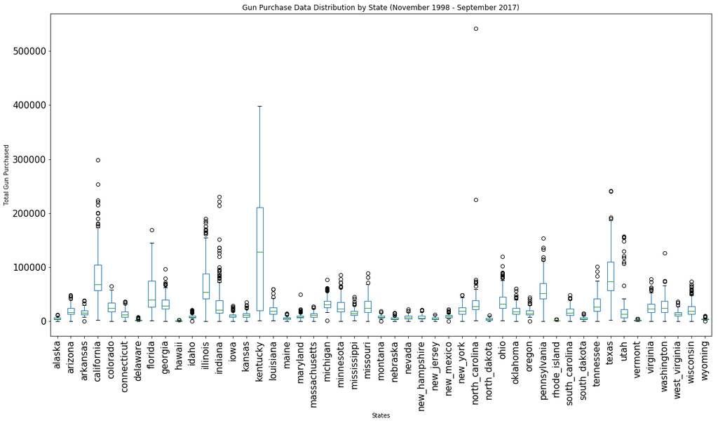

```python
#new_gun_data.groupby('state').plot(kind='boxplot');

state_list1 = gun_data_piv2.columns[2:].to_list()
state_list1
ax_5 = gun_data_piv2.boxplot(column=state_list1, figsize=(20,10),rot = 90, grid=False, fontsize=15);
ax_5.set(xlabel = "States", ylabel="Total Gun Purchased", title= 'Gun Purchase Data Distribution by State (November 1998 - September 2017)');
```

From the diagram above, none of the data is normally distributed. Most states, except Kentucky, have outliers. Most states, except Connecticut,Louisiana, New york, and West Virginia have a right-skewed distribution.

Kentucky had the longest boxplot with no outliers. This indicated that gun purchases are more consistent and spread out across all months than in any other states. The median value for Kentucky is higher than the maximum value for other states, except Washinton, Utah, Texas, Pennyslavania, Indiana, Illinois, Florida, California, and North Carolina

### Research Question 2 - Which states had the highest and the lowest gun purchases between November 1998 and September 2017?

```python
#Group the total gun purchases by states and plot a bar chat

total_permit2 = new_gun_data.groupby(["state"])["totals"].sum().reset_index(name="totals")
sorted_total_permit2 = total_permit2.sort_values(by='totals', ascending=False)

highest_gun_purchase = sorted_total_permit2['totals'].max()
lowest_gun_purchase = sorted_total_permit2['totals'].min()
print(highest_gun_purchase,lowest_gun_purchase)
```

```
29762434.0 197580.0
```

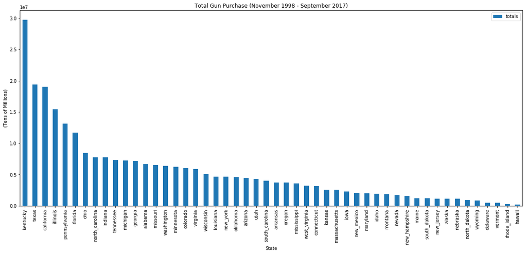

```python
ax = sorted_total_permit2.plot( x="state", y="totals", kind="bar",figsize=(20,8), title = "Total Gun Purchase (November 1998 - September 2017)");
ax.set(xlabel = "State", ylabel = "(Tens of Millions)");
```

Between November 1998 and September 2017, Kentucky had the highest gun purchase with the total of number 29,762,434. Hawaii had the lowest gun purchases with the total number of 197,580.

### Research Question 3 : What is the overall trend in gun purchase?

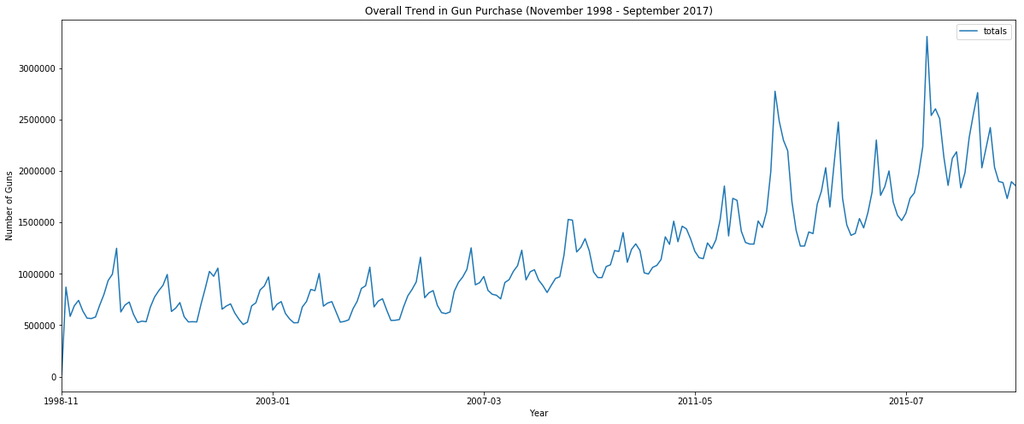

```python
# Plot the line chart to show the overall trend in gun purchase

ax2 = total_permit_by_year.plot( x="year_month", y="totals", kind="line",figsize=(20,8), title = "Overall Trend in Gun Purchase (November 1998 - September 2017)");
ax2.set(xlabel = "Year", ylabel='Number of Guns');
```

Gun purchase is on the increase. Total gun purchase as of November 1998 was 21,174 and as of September 2017, total gun purchase had increased to 1,856,214. Some spikes can be observed in the line chart below, and an analysis of the dataset shows that gun purchases drops drastically in January of every year followed by growth in gun purchase in subsequent month. December 2015 had the highest total gun purchase with the value of 3,306,435.

```python
# Check the month with the highest gun purchase

total_permit_by_year[total_permit_by_year['totals'] == total_permit_by_year.totals.max()]
```

|  | totals | year_month |
| --- | --- | --- |
| 205 | 3306435.0 | 2015-12 |

```python
#Review the months that are responsible for the observed spikes in the line chart above

total_permit_by_year
```

|  | totals | year_month |
| --- | --- | --- |
| 0 | 21174.0 | 1998-11 |
| 1 | 870202.0 | 1998-12 |
| 2 | 585569.0 | 1999-01 |
| 3 | 689867.0 | 1999-02 |
| 4 | 741234.0 | 1999-03 |
| 5 | 638299.0 | 1999-04 |
| 6 | 568781.0 | 1999-05 |
| 7 | 564521.0 | 1999-06 |
| 8 | 579263.0 | 1999-07 |
| 9 | 694469.0 | 1999-08 |
| 10 | 798738.0 | 1999-09 |
| 11 | 934384.0 | 1999-10 |
| 12 | 995378.0 | 1999-11 |
| 13 | 1247812.0 | 1999-12 |
| 14 | 628579.0 | 2000-01 |
| 15 | 695878.0 | 2000-02 |
| 16 | 725088.0 | 2000-03 |
| 17 | 606212.0 | 2000-04 |
| 18 | 526074.0 | 2000-05 |
| 19 | 539560.0 | 2000-06 |
| 20 | 533493.0 | 2000-07 |
| 21 | 675825.0 | 2000-08 |
| 22 | 773629.0 | 2000-09 |
| 23 | 835879.0 | 2000-10 |
| 24 | 888128.0 | 2000-11 |
| 25 | 993141.0 | 2000-12 |
| 26 | 633466.0 | 2001-01 |
| 27 | 665891.0 | 2001-02 |
| 28 | 719949.0 | 2001-03 |
| 29 | 583322.0 | 2001-04 |
| ... | ... | ... |
| 197 | 1696255.0 | 2015-04 |
| 198 | 1569096.0 | 2015-05 |
| 199 | 1517014.0 | 2015-06 |
| 200 | 1587710.0 | 2015-07 |
| 201 | 1734239.0 | 2015-08 |
| 202 | 1785086.0 | 2015-09 |
| 203 | 1967570.0 | 2015-10 |
| 204 | 2234871.0 | 2015-11 |
| 205 | 3306435.0 | 2015-12 |
| 206 | 2538652.0 | 2016-01 |
| 207 | 2603227.0 | 2016-02 |
| 208 | 2507513.0 | 2016-03 |
| 209 | 2134410.0 | 2016-04 |
| 210 | 1859080.0 | 2016-05 |
| 211 | 2121693.0 | 2016-06 |
| 212 | 2185520.0 | 2016-07 |
| 213 | 1835093.0 | 2016-08 |
| 214 | 1981896.0 | 2016-09 |
| 215 | 2324740.0 | 2016-10 |
| 216 | 2552584.0 | 2016-11 |
| 217 | 2761141.0 | 2016-12 |
| 218 | 2030400.0 | 2017-01 |
| 219 | 2222804.0 | 2017-02 |
| 220 | 2420835.0 | 2017-03 |
| 221 | 2035418.0 | 2017-04 |
| 222 | 1896910.0 | 2017-05 |
| 223 | 1886240.0 | 2017-06 |
| 224 | 1731550.0 | 2017-07 |
| 225 | 1894569.0 | 2017-08 |
| 226 | 1856214.0 | 2017-09 |

227 rows × 2 columns

### Research Question 4 - Which states had the highest and the lowest percent change in gun purchase between April 2010 and July 2016?

```python
# Get the indexes of July 2016 and April 2010 and extract the data for the period

print(gun_data_piv2[gun_data_piv2['year_month']=="2016-07"].index[0])
print(gun_data_piv2[gun_data_piv2['year_month']=="2010-04"].index[0])
```

```
212
137
```

```python
#Calculate the percentage change in total gun purchased between April 2010 and July 2016

gun_data_piv3.loc['percent_change(%)'] = ((gun_data_piv3.iloc[212] / gun_data_piv3.iloc[137])-1)*100
gun_data_piv3_min = gun_data_piv3.loc['percent_change(%)'].max()
```

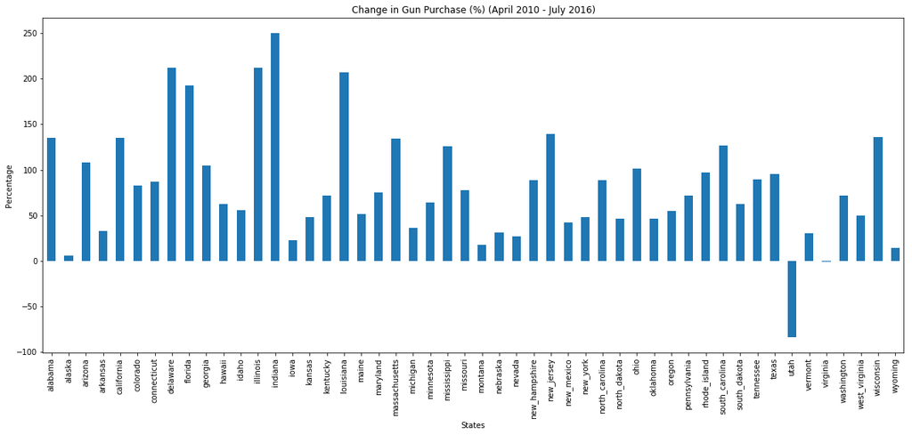

```python
# Plot the chat

ax3 = gun_data_piv3.loc['percent_change(%)'].plot(kind="bar" , figsize=(20,8), title = "Change in Gun Purchase (%) (April 2010 - July 2016)");
ax3.set(xlabel = "States");
ax3.set(ylabel = "Percentage");
```

```python
# Get the min and max values for the percent change in gun purchase

max_change = gun_data_piv3.loc['percent_change(%)'].max()
min_change = gun_data_piv3.loc['percent_change(%)'].min()
print(max_change, min_change)
```

```
250.11097019657575 -83.90361181450028
```

Indiana had the highest percent change in gun purchase with the value of 250.12%. Utah had the lowest percent change in gun purchase with the value of -83.90% for the period between April 2010 and July 2016.

### Research Question 5 - Are the changes in population size responsible for the changes in gun purchase?

```python
# Convert data type from object to float
population_change = df_census_data.iloc[[2],1:]

new_float = []
for values in df_census_data.iloc[[2],1:].values:
    values = values.astype(float)
    new_float.append(values)

df_census_data.iloc[[2],1:] = new_float

census_sub = df_census_data.iloc[[2]].set_index("fact")
census_sub
```

| fact | alabama | alaska | arizona | arkansas | california | colorado | connecticut | delaware | florida | georgia | ... | south_dakota | tennessee | texas | utah | vermont | virginia | washington | west_virginia | wisconsin | wyoming |
| --- | --- | --- | --- | --- | --- | --- | --- | --- | --- | --- | --- | --- | --- | --- | --- | --- | --- | --- | --- | --- | --- |
| Population, percent change - April 1, 2010 (estimates base) to July 1, 2016, (V2016) | 1.7 | 4.5 | 8.4 | 2.5 | 5.4 | 10.2 | 0.1 | 6 | 9.6 | 6.4 | ... | 0.063 | 0.048 | 10.8 | 10.4 | -0.2 | 5.1 | 8.4 | -1.2 | 1.6 | 3.9 |

1 rows × 50 columns

```python
#Merge the population change from census dataset with gun purchase change in the gun dataset
gun_sub = gun_data_piv3.loc[['percent_change(%)']]

new_dataframe = pd.concat([census_sub,gun_sub], sort=False)
new_dataframe
```

| state | alabama | alaska | arizona | arkansas | california | colorado | connecticut | delaware | florida | georgia | ... | south_dakota | tennessee | texas | utah | vermont | virginia | washington | west_virginia | wisconsin | wyoming |
| --- | --- | --- | --- | --- | --- | --- | --- | --- | --- | --- | --- | --- | --- | --- | --- | --- | --- | --- | --- | --- | --- |
| Population, percent change - April 1, 2010 (estimates base) to July 1, 2016, (V2016) | 1.7 | 4.5 | 8.4 | 2.5 | 5.4 | 10.2 | 0.1 | 6 | 9.6 | 6.4 | ... | 0.063 | 0.048 | 10.8 | 10.4 | -0.2 | 5.1 | 8.4 | -1.2 | 1.6 | 3.9 |
| percent_change(%) | 135.328 | 5.95851 | 108.083 | 33.0632 | 135.564 | 82.5321 | 86.8798 | 212.3 | 192.583 | 104.376 | ... | 62.3767 | 89.318 | 95.667 | -83.9036 | 30.2484 | -1.27557 | 72.1563 | 50.1878 | 136.306 | 14.2537 |

2 rows × 50 columns

```python
change_df = new_dataframe.transpose()
change_df
```

| state | Population, percent change - April 1, 2010 (estimates base) to July 1, 2016, (V2016) | percent_change(%) |
| --- | --- | --- |
| alabama | 1.7 | 135.328 |
| alaska | 4.5 | 5.95851 |
| arizona | 8.4 | 108.083 |
| arkansas | 2.5 | 33.0632 |
| california | 5.4 | 135.564 |
| colorado | 10.2 | 82.5321 |
| connecticut | 0.1 | 86.8798 |
| delaware | 6 | 212.3 |
| florida | 9.6 | 192.583 |
| georgia | 6.4 | 104.376 |
| hawaii | 5 | 62.513 |
| idaho | 7.4 | 55.5413 |
| illinois | -0.2 | 211.942 |
| indiana | 2.3 | 250.111 |
| iowa | 2.9 | 22.8086 |
| kansas | 1.9 | 48.3891 |
| kentucky | 2.2 | 71.8656 |
| louisiana | 3.3 | 207.059 |
| maine | 0.2 | 51.8234 |
| maryland | 4.2 | 74.8856 |
| massachusetts | 4 | 134.111 |
| michigan | 0.4 | 36.6164 |
| minnesota | 4.1 | 64.5782 |
| mississippi | 0.7 | 125.799 |
| missouri | 1.7 | 77.4012 |
| montana | 5.4 | 17.9515 |
| nebraska | 4.4 | 31.1036 |
| nevada | 8.9 | 26.8022 |
| new_hampshire | 1.4 | 89.0899 |
| new_jersey | 1.7 | 139.004 |
| new_mexico | 0.011 | 42.0979 |
| new_york | 0.019 | 48.2618 |
| north_carolina | 0.064 | 88.7373 |
| north_dakota | 0.127 | 46.8062 |
| ohio | 0.007 | 101.673 |
| oklahoma | 0.046 | 46.1746 |
| oregon | 0.068 | 54.7814 |
| pennsylvania | 0.006 | 71.4203 |
| rhode_island | 0.003 | 97.4979 |
| south_carolina | 0.073 | 126.646 |
| south_dakota | 0.063 | 62.3767 |
| tennessee | 0.048 | 89.318 |
| texas | 10.8 | 95.667 |
| utah | 10.4 | -83.9036 |
| vermont | -0.2 | 30.2484 |
| virginia | 5.1 | -1.27557 |
| washington | 8.4 | 72.1563 |
| west_virginia | -1.2 | 50.1878 |
| wisconsin | 1.6 | 136.306 |
| wyoming | 3.9 | 14.2537 |

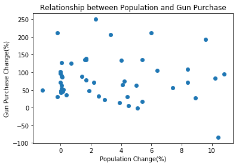

```python
# Plot a scatter graph of the relationship

x = new_dataframe.iloc[0].values
y = new_dataframe.iloc[1].values

plt.scatter(x, y)
plt.title('Relationship between Population and Gun Purchase')
plt.xlabel('Population Change(%)')
plt.ylabel('Gun Purchase Change(%)');
```

## Conclusions

While increase in crime rate could explain the increase in gun purchase, this data is not provided. Information about the crime rate can be obtained from U.S. Crime Rate & Statistics.

Despite the upward trend, January of every year always experience a significant drop in the number of gun purchase. Tight budget due to the holiday shopping in the prior month(December) could be responsible for this drop. A review of consumer spending, or personal consumption expenditures (PCE) data by the US Bureau of Economic Analysis could provide insight on consumer spending in January.

### Limitations

The major limitation was combining the data from the two tables based on the state. This is because the state data for the census dataset is located on the columns axis but the state data for the gun purchase data is located on the row axis.

```python
from subprocess import call
call(['python', '-m', 'nbconvert', 'Investigate_a_Dataset.ipynb'])
```

```
0
```